# Estruturas de Mercado, Barreiras de Entrada e Aglomerações Produtivas

Empreendedorismo Tecnológico e Desenvolvimento Territorial · Aula 02

Prof. Dr. Luiz Diego Vidal Santos

## Unidade I Visão geral da aula

**01 · Estruturas de mercado:** Concorrência, oligopólio, monopólio e poder de mercado.

**02 · Cinco Forças:** Modelo estrutural de competitividade setorial de Porter.

**03 · Barreiras:** Entrada, saída, custos de mudança e estratégias genéricas.

**04 · Espaço vs. território:** Dos *clusters* de Porter aos APLs (RedeSist).

**05 · Competitividade:** Espúria vs. autêntica e inserção de PMEs e *startups*.

Propósito formativo Objetivo da aula

Analisar como as **estruturas de mercado** e as **barreiras de entrada** condicionam a sobrevivência de novos empreendimentos tecnológicos, e compreender como *clusters* e Arranjos Produtivos Locais (APLs) reduzem custos de entrada no território.

5 Forças de Porter Barreiras de Entrada APLs & RedeSist

**Fio condutor:** Como pequenos empreendimentos territoriais superam escalas oligopolistas por meio de diferenciação e eficiência coletiva?

# Estruturas de Mercado

## Conceito Tipologia clássica e dinâmica concorrencial

| Estrutura | Nº de Firmas | Produto | Barreira à Entrada | Poder de Preço |
| --- | --- | --- | --- | --- |
| **Concorrência Perfeita** | Muitas | Homogêneo | Nula | Nulo (tomadora) |
| **Concorrência Monopolística** | Muitas | Diferenciado | Baixa | Limitado |
| **Oligopólio** | Poucas | Homog. ou Difer. | Alta | Elevado (interdependente) |
| **Monopólio** | Uma | Único (sem subst.) | Muito Alta / Legal | Máximo (regulado ou não) |

Estratégia tecnológica Leitura para base tecnológica

- *Startups* frequentemente buscam criar um **monopólio temporário** via inovação/PI (Thiel; Schumpeter) antes que imitadores entrem.
- Em cadeias tradicionais (agro, energia, construção), novos entrantes enfrentam **oligopólios** consolidados.

**Efeito territorial:** Mercados oligopolizados tendem a concentrar margem fora do território produtor (ex.: *commodities* sem beneficiamento local).

# Cinco Forças e Barreiras de Entrada

## Conceito O modelo das Cinco Forças (Porter, 1979; 1980)

Pressões estruturais As Cinco Forças competitivas

1. **Rivalidade entre concorrentes existentes** (crescimento do setor, custos fixos, diferenciação).
2. **Ameaça de novos entrantes** (altura das barreiras à entrada e retaliação esperada).
3. **Ameaça de produtos ou serviços substitutos** (razão preço–desempenho).
4. **Poder de barganha dos compradores** (concentração, sensibilidade a preço, integração para trás).
5. **Poder de barganha dos fornecedores** (concentração, insumos críticos, custo de troca).

Fatores de proteção As 6 principais barreiras à entrada

- **Economias de escala:** custo unitário cai com volume (exige entrada em larga escala ou desvantagem de custo).
- **Diferenciação e lealdade à marca:** exige alto gasto em posicionamento.
- **Necessidades de capital:** investimento inicial elevado em P&D ou ativos fixos.
- **Custos de mudança (*Switching Costs*):** custo técnico/operacional para trocar de fornecedor.
- **Acesso a canais de distribuição** e insumos críticos.
- **Desvantagens independentes de escala:** patentes, curva de aprendizagem, **localização favorável** e subsídios/regulação.

## Síntese Cinco Forças e eficiência coletiva

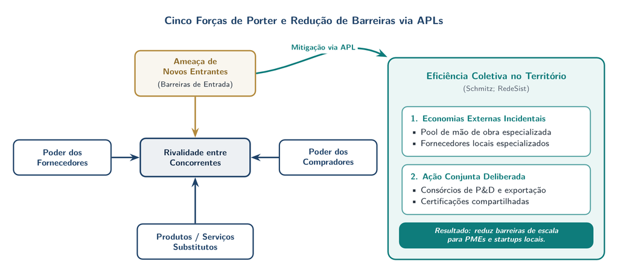

Articulação entre as Cinco Forças Competitivas de Porter e a redução de barreiras à entrada via economias externas e ação conjunta em APLs e clusters.

Cinco Forças de Porter e mitigação de barreiras via APLs Economias externas incidentais e ação conjunta deliberada (Schmitz; RedeSist) reduzem barreiras de escala para PMEs e startups locais

A eficiência coletiva atua diretamente sobre as barreiras de escala, capital e acesso a mercados que bloqueariam firmas isoladas.

## Método Barreiras à saída e estratégias genéricas

|  | **Barreiras de Saída Baixas** | **Barreiras de Saída Altas** |
| --- | --- | --- |
| **Entrada Baixa** | Retornos baixos e estáveis | Retornos baixos e arriscados |
| **Entrada Alta** | Retornos altos e estáveis | Retornos altos e arriscados |

Rigidez estrutural Barreiras à saída

Ativos altamente especializados, custos trabalhistas e ambientais de desmobilização, inter-relações estratégicas e barreiras emocionais ou políticas.

Posicionamento (Porter, 1980) Estratégias genéricas

1. **Liderança em Custo Total:** escala, eficiência operacional e controle rígido.
2. **Diferenciação:** atributo único valorizado (tecnologia proprietária, origem territorial, qualidade).
3. **Enfoque (Nicho):** foco em segmento, linha ou **território específico** (por custo ou diferenciação).

**Armadilha do “Meio-Termo” (*Stuck in the Middle*):** PMEs territoriais sem escala para competir em custo nem diferenciação clara perdem margem.

# Clusters, Distritos e APLs no Território

## Território Da firma isolada à eficiência coletiva

Economia da aglomeração Por que aglomerações reduzem barreiras?

- **Distritos Industriais (Marshall, 1890):** externalidades pecuniárias e tecnológicas (*pool* de mão de obra, fornecedores especializados, *spillovers*).
- **Eficiência Coletiva (Schmitz, 1995):** soma de **economias externas incidentais** + **ação conjunta deliberada** (consórcios, feiras, centros tecnológicos).
- *Clusters* (Porter, 1998): concentrações geográficas de empresas interconectadas, fornecedores e instituições em um campo específico.

RedeSist / IE-UFRJ Arranjos Produtivos Locais (Cassiolato & Lastres, 2005)

- Enfatiza **enraizamento territorial**, aprendizado interativo e redução de assimetrias para PMEs.
- **Diferença crítica:** Um *cluster* pode existir apenas por aglomeração de mercado; um **APL** pressupõe articulação institucional e governança local para inovação.

**Conexão Edital + Território:** Em APLs bem estruturados, barreiras de entrada individuais (P&D, certificação, canais de exportação) são **compartilhadas** entre pequenos produtores e empresas.

## Caso Ativos territoriais e APLs: cacau cabruca no Sul da Bahia

Ativo territorial específico Agroecossistema cacau-cabruca (Ilhéus / Sul da Bahia)

O cultivo sombreado sob remanescentes da Mata Atlântica articula conservação florestal, saber-fazer tradicional e identidade de origem — convertendo um ativo socioecológico em **diferenciação não facilmente imitável**.

Ação conjunta no APL Superando barreiras de escala e margem

Quando produtores, cooperativas e ICTs atuam em rede — compartilhando P&D, fermentação de qualidade, certificações e agroindústria local — rompem a dependência da venda de *commodity* bruta.

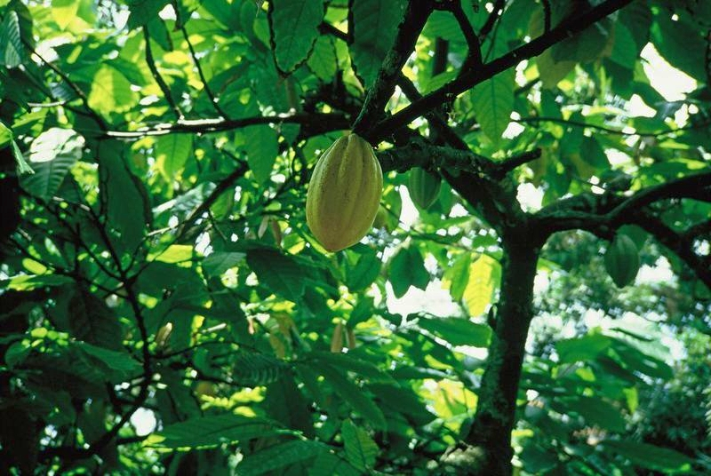

Fruto de cacau em sistema agroflorestal cabruca no Sul da Bahia.

Agroecossistema cacau-cabruca (Ilhéus / Sul da Bahia) Ativo territorial para diferenciação produtiva e governança em APL

## Crítica Espaço neutro vs. território social

Porter (1998) e Barney (1991) Limites da visão mercadológica

- **Porter (*Clusters*):** trata a aglomeração prioritariamente como mecanismo de redução de custos de transação e ganho de poder de barganha mercadológico.
- **Barney (RBV / VRIO):** foca em recursos internos da firma protegidos por ambiguidade causal e complexidade social, subestimando a construção coletiva de capacidades no território.

Cassiolato & Lastres / RedeSist A crítica latino-americana

- O território **não é um palco físico neutro**: é uma construção histórica, institucional e política marcada por assimetrias de poder.
- **Competitividade espúria vs. autêntica:** aglomerações baseadas em baixos salários, precarização ou exaustão ambiental não geram desenvolvimento regional.
- Nos **APLs**, a vantagem duradoura depende de **cooperação institucional**, confiança tácita, aprendizado interativo e inclusão produtiva.

## Método Oficina aplicada e leituras (Eixo 2)

**Análise estrutural aplicada (45 min):** Escolha uma cadeia regional (fruticultura irrigada do São Francisco, sisal/fibras naturais, *software*/serviços digitais ou energia solar distribuída) e elabore:

**01 · Mapa das 5 Forças de Porter** para uma *startup* ou PME entrante nesse setor.

**02 · Gargalos competitivos:** Identificação das **2 maiores barreiras à entrada** existentes.

**03 · Eficiência coletiva:** Proposta de **ação conjunta (APL/*Cluster*)** para reduzir essas barreiras no território.

Bibliografia fundamental Leituras da Aula 02 e próxima aula (Eixo 2)

- **PORTER, M. E.** *Clusters and the new economics of competition*. HBR, 1998; *Estratégia competitiva*. Elsevier, 2004.
- **BARNEY, J.** *Firm resources and sustained competitive advantage*. Journal of Management, 1991.
- **CASSIOLATO, J. E.; LASTRES, H. M. M.** *Sistemas de inovação e desenvolvimento* (RedeSist/APLs). São Paulo em Perspectiva, 2005.
- **STAM, E.** *Entrepreneurial ecosystems and regional policy: a sympathetic critique*. European Planning Studies, 2015.
- **BOSCHMA, R.** *Proximity and innovation: a critical assessment*. Regional Studies, 2005.